# tidyverse_datvisualisation

Manojit Sarkar

17 July 2018

# Lets start!

## Data Visualisation

we start of with loading the ggplot 2 library / or the tidyverse library

Here i will be just loading the ggplot2 library note :- if the libraries arre missing you can download it by typing the following

install.packages(“packagename”)

```r
library(ggplot2)
```

we will be using the same dataset as before the gapminder data set

if not installed : install it with the following line of code

```r
#install.packages("gapminder")
```

lets load the package

```r
library(gapminder)
```

Then install the dplyr package

```r
library(dplyr)
```

We will be working with the data pertaining to the year 2007 of gapminder and store it in a new data set gapminder_2007

For this we will be using the dplyr package :: filter verb

```r
gapminder_2007<-gapminder%>%
  filter(year==2007)
```

let us inspect the new dataset

```r
gapminder_2007
```

```
## # A tibble: 142 x 6
##    country     continent  year lifeExp       pop gdpPercap
##    <fct>       <fct>     <int>   <dbl>     <int>     <dbl>
##  1 Afghanistan Asia       2007    43.8  31889923      975.
##  2 Albania     Europe     2007    76.4   3600523     5937.
##  3 Algeria     Africa     2007    72.3  33333216     6223.
##  4 Angola      Africa     2007    42.7  12420476     4797.
##  5 Argentina   Americas   2007    75.3  40301927    12779.
##  6 Australia   Oceania    2007    81.2  20434176    34435.
##  7 Austria     Europe     2007    79.8   8199783    36126.
##  8 Bahrain     Asia       2007    75.6    708573    29796.
##  9 Bangladesh  Asia       2007    64.1 150448339     1391.
## 10 Belgium     Europe     2007    79.4  10392226    33693.
## # ... with 132 more rows
```

Cool!! We are now ready with our data set to carry out visualisation.

Lets do our fist visualisation usiing the ggplot2::ggplot

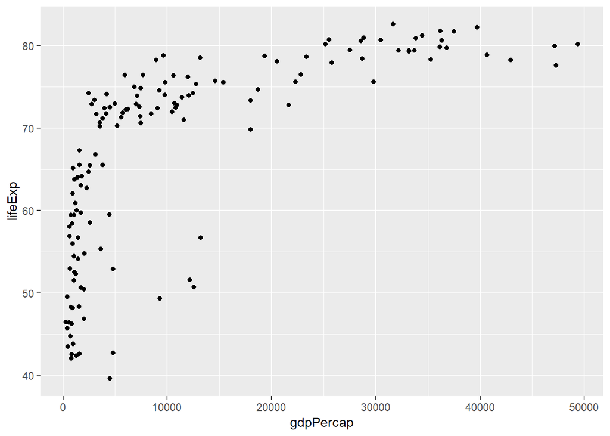

```r
ggplot(gapminder_2007,aes(x=gdpPercap,y=lifeExp))+geom_point()
```

Wow!!! isn’t that a wonderful scatter plot.

We just plotted a scatter plot between gdpPercap in x axis and lifeExp in the Y axis.

# Log Scales

one of the problem with the plot is that lot of countries gets crammed in the lesft most part of the x -axis. this is because the gdp per capita spans over several order of magnitude, with some contries in tens of thousands of dollars and others in hundreds. When ne of your axes has such kind of distribution it is useful to work with a logrithmatic scale that is a scale where each fixed distances is multiplication of the value. So lets use the log scale on x axis.

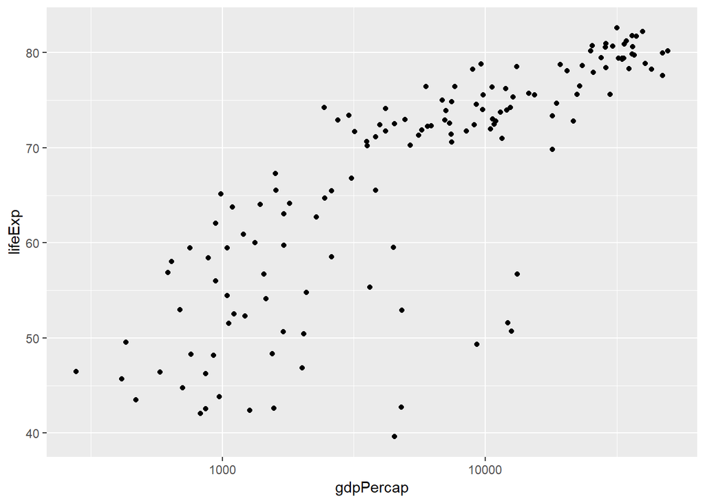

```r
ggplot(gapminder_2007,aes(x=gdpPercap,y=lifeExp))+geom_point()+scale_x_log10()
```

this is the same data as abve but now each unit on the x-axis represents a change of 10 times the GDP. you can see that the x axis goes from 1000 to 10000 and the next will go 100000. On this scale the relationship looks more linear and one can more easily distinguish the countries on the lower end of the spectrum.

We can add log scales on both x nd y axes.

## Additional Aesthetics (aes)

size and color.

Continent is a categorical variable with five levels. A good way to represent a categorical variable in a scatter plot is by color of the points. lets try it for overselves.

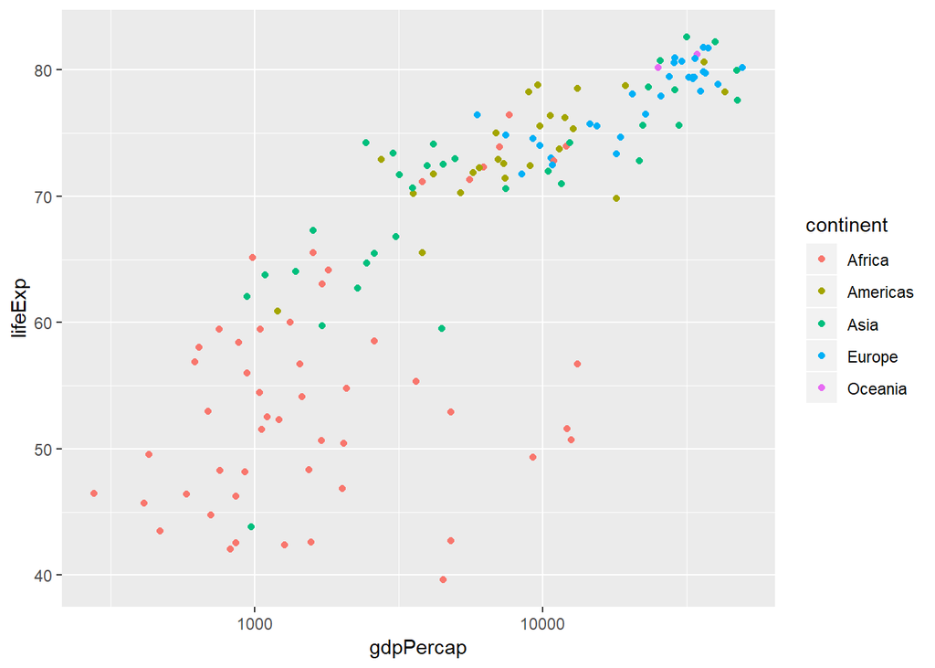

```r
ggplot(gapminder_2007,aes(x=gdpPercap,y=lifeExp,color=continent))+geom_point()+scale_x_log10()
```

Now size aesthetics

population “pop” is a numeric variable and a good way to represent a numeric variable is size aesthetics. So lets do it.

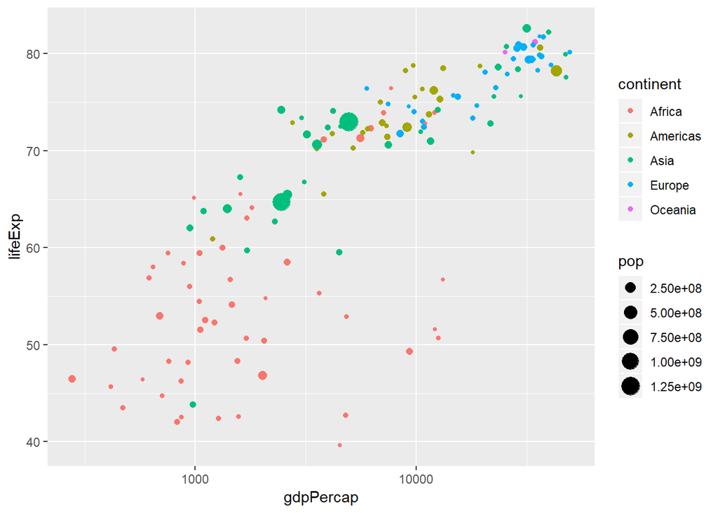

```r
ggplot(gapminder_2007,aes(x=gdpPercap,y=lifeExp,color=continent,size=pop))+geom_point()+scale_x_log10()
```

## Faceting

ggplot2 allows us to divide our plots into sub plots to get one small graph. This is called faceting.

Mostly its used on categorical varibles and we will use it with the variable continent.

lets try it out

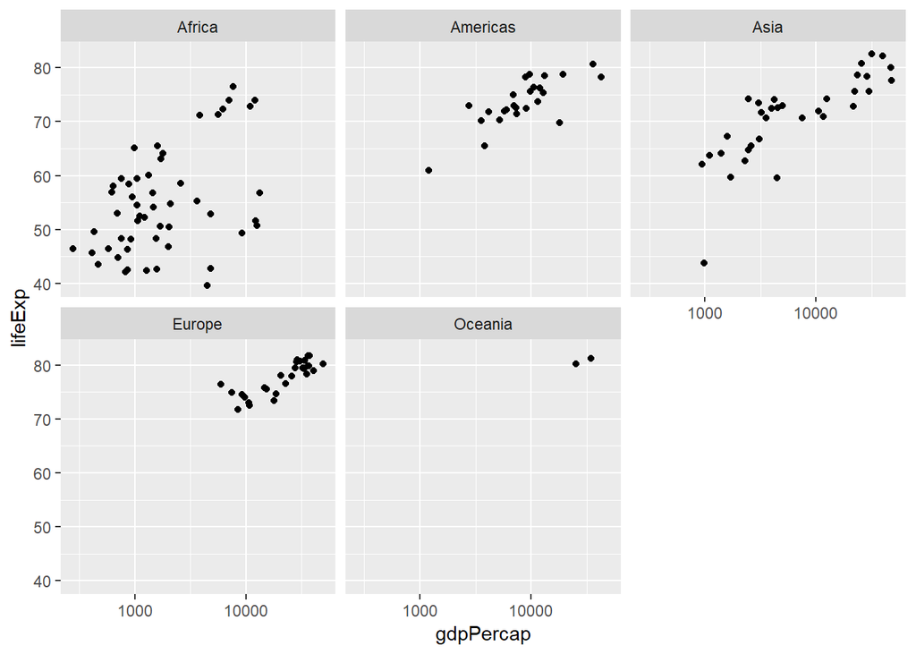

```r
ggplot(gapminder_2007,aes(x=gdpPercap,y=lifeExp))+geom_point()+scale_x_log10()+facet_wrap(~continent)
```

lets do more faceting examples :-

–Scatter plot comparing gdpPercap and lifeExp , with color representing continent and size representing population, faceted by year

for comparing with year we will have to use the gapminder dataset

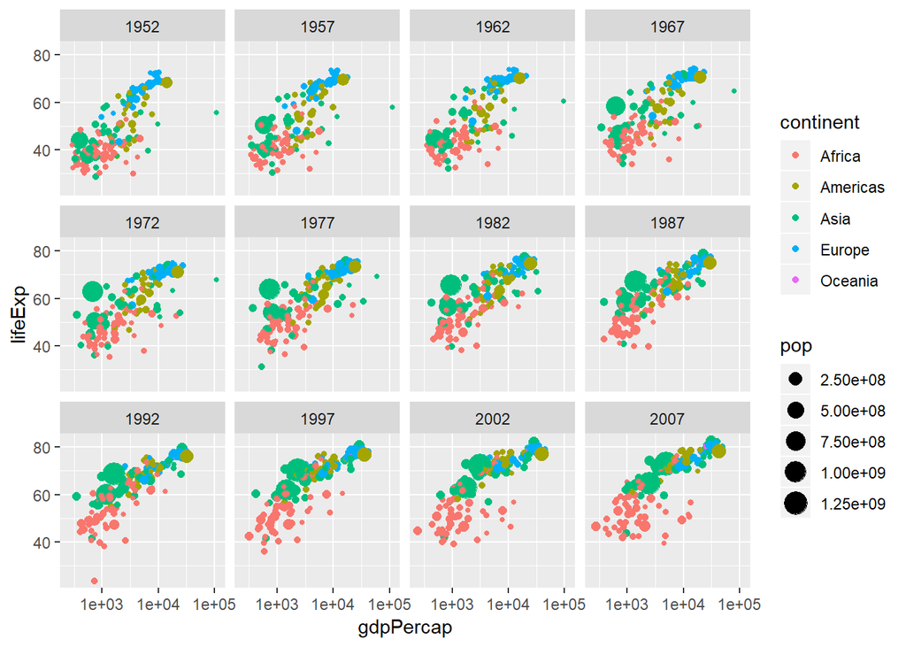

```r
ggplot(gapminder,aes(x=gdpPercap,y=lifeExp,color=continent,size=pop))+geom_point()+scale_x_log10()+facet_wrap(~year)
```

Thats all for intro into Tidyverse_Visualisation !!! May the force be with you!!!